# Efficient R Programming

Colin Gillespie ([@csgillespie](https://twitter.com/csgillespie))

Jumping Rivers ([@jumping_uk](https://twitter.com/jumping_uk))

## Tutorial R Package

Contains copies of slides and exercises

```r
install.packages("drat")
drat::addRepo("jr-packages")
install.packages("efficientTutorial")
```

- Repo at https://github.com/jr-packages/efficientTutorial
- Slides at https://jumpingrivers.com/t/2018-efficient-erum

## Who am I

- Dr Colin Gillespie
  - Senior Statistics Lecturer, Newcastle University
  - Consultant at [Jumping Rivers](https://jumpingerivers.com)

## Jumping Rivers

- Statistical and R consultancy
- R, Scala, python, & Stan training
- Predictive analytics
- Dashboard development
- In-house training

# Who are you? Time to make a friend

## Who are you?

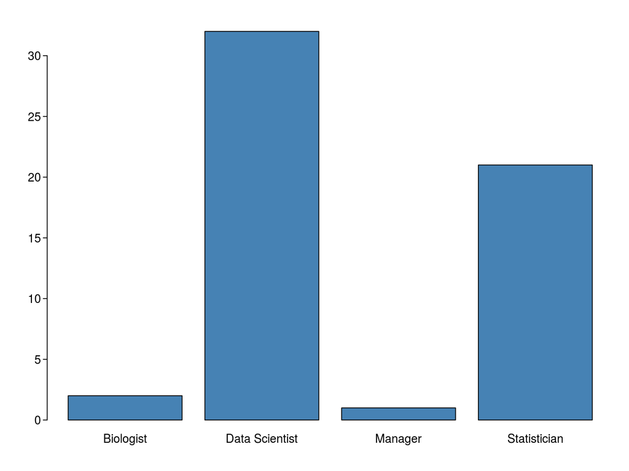

We also have a *Transitionning Physicist* in the room

## Functions & loops

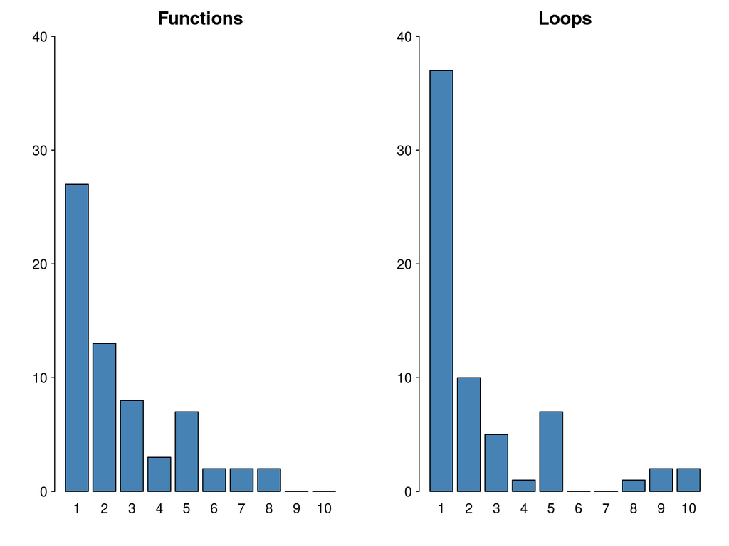

## Other bits and pieces

- Around 40% of people have built a package
- Most people haven’t used C/C++

## Todays tutorial

- Small subset of efficient R programming course
- Based https://github.com/csgillespie/efficientR

```r
## Slides
browseVignettes("efficientTutorial")
```

## What we won’t cover

- Rcpp in depth
- dplyr and friends
- The joys of git and reproducible research
- Pipes
- Big data
- Statistics

## What we do cover

- Byte Compiling (only for 5 minutes)
- Low hanging targets
- Your startup file
- Learning
- Code Profiling
- Parallel Computing
- Rcpp

> The goal is to give a flavour of the topics

# Optimisation

## Optimisation

> The real problem is that programmers have spent far too much time worrying about efficiency in the wrong places and at the wrong times; premature optimization is the root of all evil (or at least most of it) in programming.

**Donald Knuth**

## Timing code

- `system.time()`
- `microbenchmark()`

## `system.time()`

- Easy to use

  ```r
  ## <- vs =
  ## Using <- here creates an object `x`
  ## Using = raises an errror
  system.time(x <- rnorm(1000000)^2.3)
  ```

  ```
  ##    user  system elapsed
  ##   0.159   0.000   0.159
  ```

- Hard to compare multiple benchmarks

## `microbenchmark()`

- `microbenchmark()` makes it easy to compare multiple functions
- Example: matrix (`d_m`) vs data frame (`d_df`)
- Selecting Rows and columns

```r
library("microbenchmark")
(res = microbenchmark(times = 1000,
               unit = "ms", # milliseconds
           d_m[1,], d_df[1,], d_m[,1], d_df[,1]))
#Unit: milliseconds
#      expr   min    lq   mean  median      uq      max neval cld
#  d_m[1, ] 0.004 0.008  0.014   0.014  0.0204    0.049  1000  a
# d_df[1, ] 4.722 5.067  5.681   5.333  5.6767  109.383  1000   b
#  d_m[, 1] 0.006 0.006  0.007   0.007  0.0081    0.024  1000  a
# d_df[, 1] 0.006 0.008  0.012   0.012  0.0153   0.0558  1000  a
```

## Plotting method

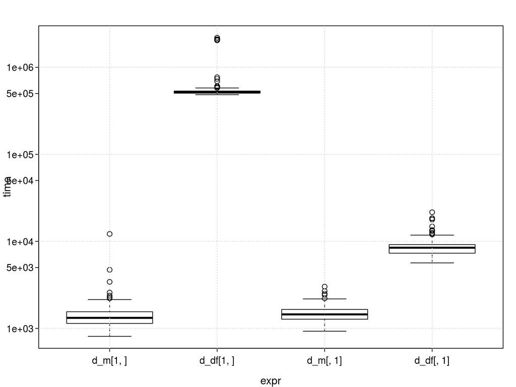

```r
plot(res, log="y")
```

## data frame vs matrix

- All data in a matrix must be the same type
- Less overhead than a data frame, so faster

## eRum Resolution

> Never ask on Stackoverflow which method is faster!